# 1. Prepare a data quality report for the CSV file.

### Overall check

```python
# Check if there still have null values and if the columns were dropped succesfully
df.isnull().sum()
```

```
case_month                         0
res_state                          0
res_county                         0
county_fips_code                   0
age_group                          0
sex                                0
race                               0
ethnicity                          0
case_positive_specimen_interval    0
case_onset_interval                0
current_status                     0
symptom_status                     0
hosp_yn                            0
death_yn                           0
underlying_conditions_yn           0
dtype: int64
```

```python
# Write the cleaned dataframe to a csv file
df.to_csv('cleaned-covid19-cdc-1_2-22200055.csv', index=False)
```

# 3. Exploring relationships between feature pairs:

### Choose a subset of features you find promising and plot pairwise feature interactions (e.g., continuous-continuous feature plot or continuous-categorical plots or correlation plots). Explain your choices.

The features that I will look at for pairwise feature interaction are the following continuous features:

- case_positive_specimen_interval
- case_onset_interval

and the following categorical features VS 'death_yn':

- case_month
- age_group
- race
- symptom_status
- underlying_conditions_yn

The choices here I based on the idea that these particular features would be strong markers to track cases, deaths, and trends of COVID-19 in the United States, as also discussed based on plots in the Yu-Feng-22200055-Data_Quality_Report_Initial_Findings.pdf.

### Categorical vs Categorical feature plots

```
case_month
Index 	 Count
2020-11 	 1230
2020-12 	 1550
2021-11 	 607
2020-08 	 367
2020-04 	 680
2021-12 	 1300
2021-08 	 846
2022-01 	 2341
2020-03 	 288
2020-05 	 331
2021-09 	 747
2020-10 	 586
2021-01 	 1346
2021-07 	 319
2020-06 	 322
2020-09 	 311
2020-01 	 4
2021-10 	 508
2022-05 	 549
2020-07 	 513
2022-07 	 439
2022-02 	 388
2022-09 	 213
2022-06 	 398
2021-02 	 506
2021-04 	 393
2022-08 	 419
2021-05 	 166
2022-04 	 256
2021-03 	 436
2022-10 	 176
2022-03 	 138
2021-06 	 90
2020-02 	 3
```

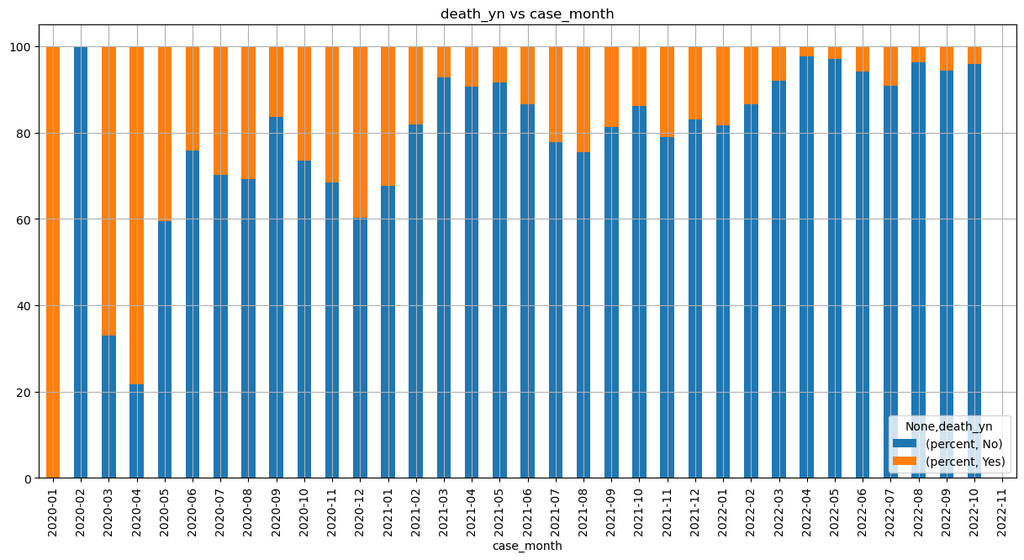

```python
#Using code from the module lab
case_month = pd.unique(df["case_month"].ravel())


# add new column and set values to zero
df['percent'] = 0

#print header
print("case_month")
print("Index \t Count")

# for each age_group category
for i in case_month:

    count = df[df["case_month"] == i].count()['death_yn']
    count_percentage = (1 / count) * 100

    # print out index vs count
    print(i, "\t", count)

    index_list = df[df['case_month'] == i].index.tolist()
    for ind in index_list:
        df.loc[ind, 'percent'] = count_percentage

group = df[['percent','case_month','death_yn']].groupby(['case_month','death_yn']).sum()

my_plot = group.unstack().plot(kind='bar', stacked=True, title="death_yn vs case_month", figsize=(15,7), grid=True)
```

We can see the stacked bar plot for case_month against the death_yn outcome.

- On first indication the figures are as expected.
- There is a trend of decreasing likelihood of death rate outcomes as case month increases.

```
age_group
Index 	 Count
65+ years 	 5726
50 to 64 years 	 3122
18 to 49 years 	 7253
Unknown 	 186
0 - 17 years 	 2479
```

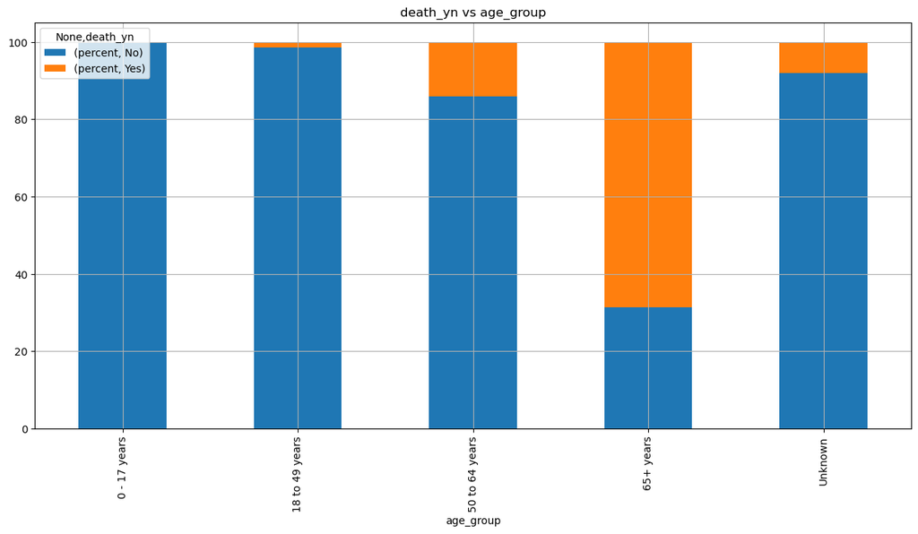

```python
#Using code from the module lab
age_group = pd.unique(df["age_group"].ravel())


# add new column and set values to zero
df['percent'] = 0

#print header
print("age_group")
print("Index \t Count")

# for each age_group category
for i in age_group:

    count = df[df["age_group"] == i].count()['death_yn']
    count_percentage = (1 / count) * 100

    # print out index vs count
    print(i, "\t", count)

    index_list = df[df['age_group'] == i].index.tolist()
    for ind in index_list:
        df.loc[ind, 'percent'] = count_percentage

group = df[['percent','age_group','death_yn']].groupby(['age_group','death_yn']).sum()

my_plot = group.unstack().plot(kind='bar', stacked=True, title="death_yn vs age_group", figsize=(15,7), grid=True)
```

We can see the stacked bar plot for age_group against the death_yn outcome.

- On first indication the figures are as expected.
- There is a clear trend of increasing likelihood of death rate outcomes as age increases.

```
race
Index 	 Count
White 	 11644
Black 	 2008
Unknown 	 4474
Asian 	 419
American Indian/Alaska Native 	 75
Multiple/Other 	 145
Native Hawaiian/Other Pacific Islander 	 1
```

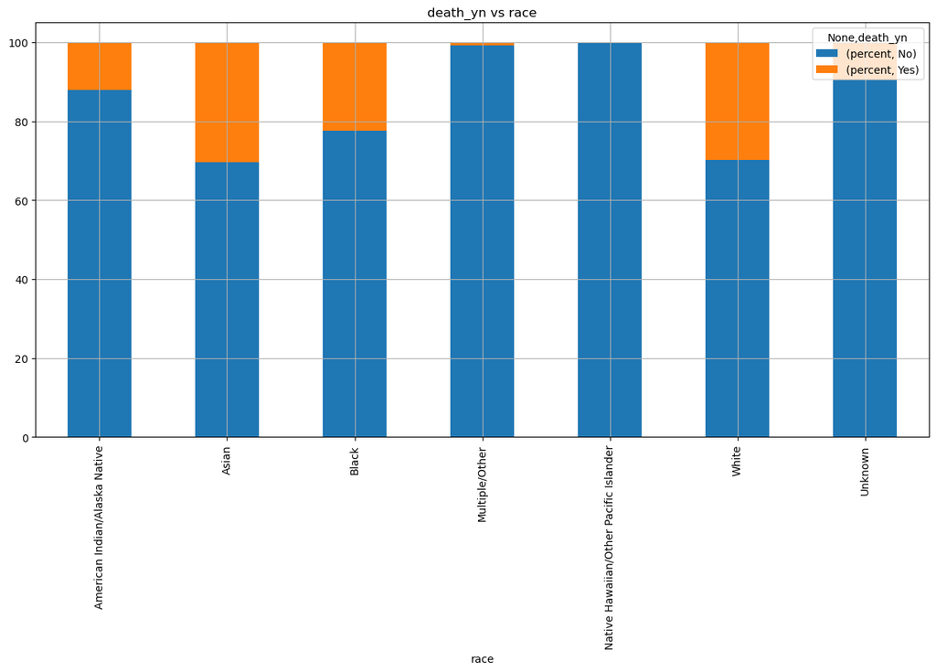

```python
#Using code from the module lab
race = pd.unique(df["race"].ravel())


# add new column and set values to zero
df['percent'] = 0

#print header
print("race")
print("Index \t Count")

# for each age_group category
for i in race:

    count = df[df["race"] == i].count()['death_yn']
    count_percentage = (1 / count) * 100

    # print out index vs count
    print(i, "\t", count)

    index_list = df[df['race'] == i].index.tolist()
    for ind in index_list:
        df.loc[ind, 'percent'] = count_percentage

group = df[['percent','race','death_yn']].groupby(['race','death_yn']).sum()

my_plot = group.unstack().plot(kind='bar', stacked=True, title="death_yn vs race", figsize=(15,7), grid=True)
```

We can see the stacked bar plot for race against the death_yn outcome.

- Asians and Whites had the highest likelihood of death cases.
- Natice Hawaiian/Other pacific Islanders were the least likely to have a fatality.
- This factor could be very complicated since this will involve many other factors, such as population density, geographic climate, etc.

```
symptom_status
Index 	 Count
Unknown 	 9606
Symptomatic 	 8866
Asymptomatic 	 294
```

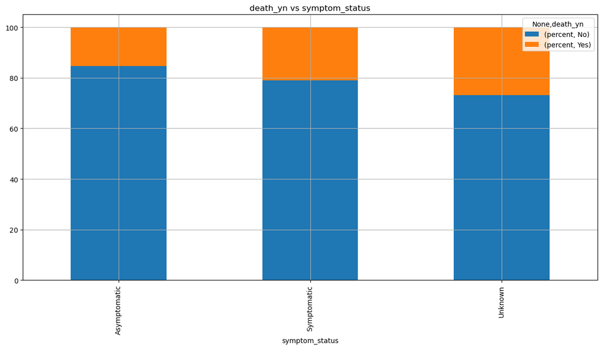

```python
#Using code from the module lab
symptom_status = pd.unique(df["symptom_status"].ravel())


# add new column and set values to zero
df['percent'] = 0

#print header
print("symptom_status")
print("Index \t Count")

# for each age_group category
for i in symptom_status:

    count = df[df["symptom_status"] == i].count()['death_yn']
    count_percentage = (1 / count) * 100

    # print out index vs count
    print(i, "\t", count)

    index_list = df[df['symptom_status'] == i].index.tolist()
    for ind in index_list:
        df.loc[ind, 'percent'] = count_percentage

group = df[['percent','symptom_status','death_yn']].groupby(['symptom_status','death_yn']).sum()

my_plot = group.unstack().plot(kind='bar', stacked=True, title="death_yn vs symptom_status", figsize=(15,7), grid=True)
```

We can see the stacked bar plot for symptom_status against the death_yn outcome.

- There was a trend for symptomatic cases to have a higher likelihood of mortality outcome.
- The difference is not so significant.

```
underlying_conditions_yn
Index 	 Count
Unknown 	 17046
Yes 	 1698
No 	 22
```

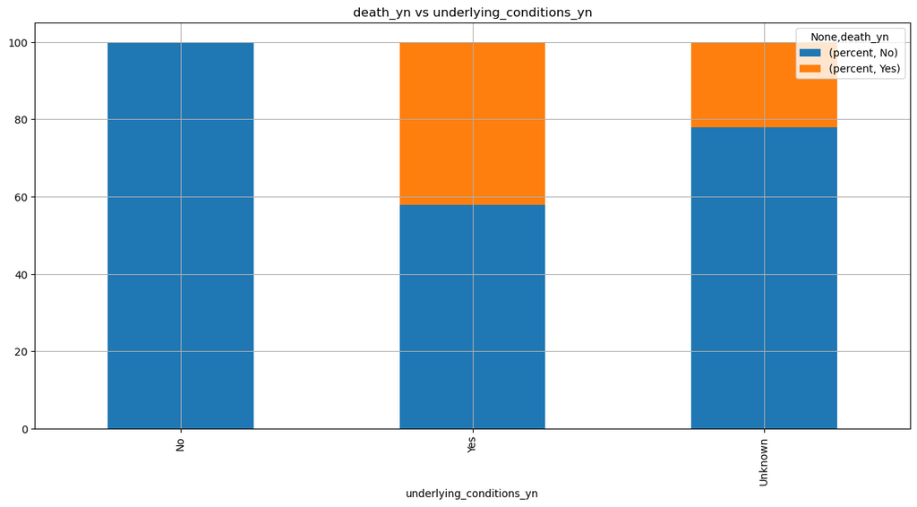

```python
#Using code from the module lab
underlying_conditions_yn = pd.unique(df["underlying_conditions_yn"].ravel())


# add new column and set values to zero
df['percent'] = 0

#print header
print("underlying_conditions_yn")
print("Index \t Count")

# for each underlying_conditions_yn category
for i in underlying_conditions_yn:

    count = df[df["underlying_conditions_yn"] == i].count()['death_yn']
    count_percentage = (1 / count) * 100

    # print out index vs count
    print(i, "\t", count)

    index_list = df[df['underlying_conditions_yn'] == i].index.tolist()
    for ind in index_list:
        df.loc[ind, 'percent'] = count_percentage

group = df[['percent','underlying_conditions_yn','death_yn']].groupby(['underlying_conditions_yn','death_yn']).sum()

my_plot = group.unstack().plot(kind='bar', stacked=True, title="death_yn vs underlying_conditions_yn", figsize=(15,7), grid=True)
```

We can see the stacked bar plot for underlying_conditions_yn against the death_yn outcome.

- On first indication the figures are as expected.
- There was a obvious trend for people having underlying medical conditions to have a higher likelihood of mortality outcome.

### Continuous VS categorical feature plots

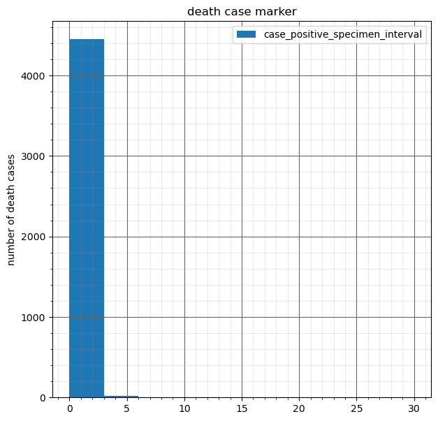

```python
df[df['death_yn'] == "Yes"][['case_positive_specimen_interval']].plot(kind='hist',figsize=(7,7), bins=10, title="death case marker")
plt.grid(which='major', color='#666666', linestyle='-')
plt.ylabel('number of death cases')
plt.minorticks_on()
plt.grid(which='minor', color='#999999', linestyle='-', alpha=0.2)
plt.show()
```

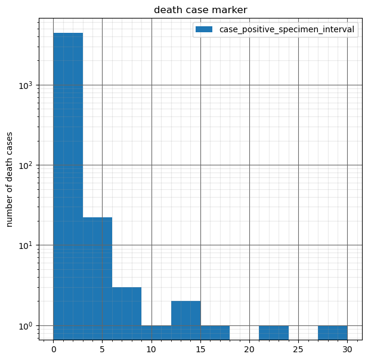

```python
# plot with log = True args
df[df['death_yn'] == "Yes"][['case_positive_specimen_interval']].plot(kind='hist',figsize=(7,7), bins=10, title="death case marker", log = True)
plt.grid(which='major', color='#666666', linestyle='-')
plt.ylabel('number of death cases')
plt.minorticks_on()
plt.grid(which='minor', color='#999999', linestyle='-', alpha=0.2)
```

We can see the stacked bar plot for case_positive_specimen_interval against the death_yn outcome.

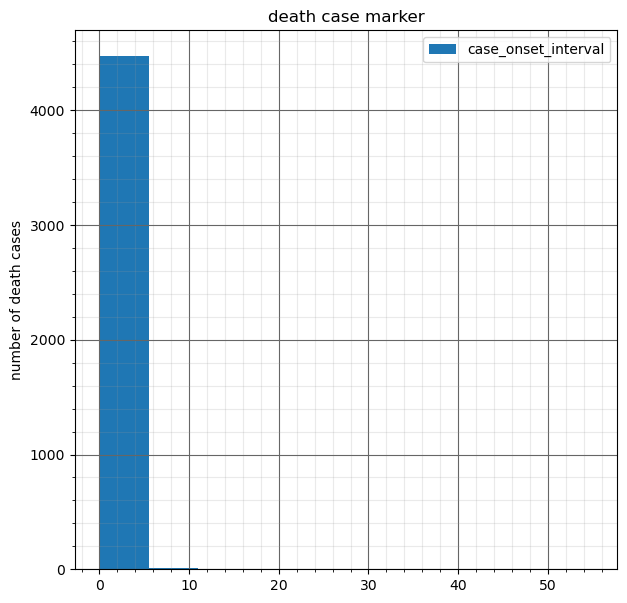

```python
df[df['death_yn'] == "Yes"][['case_onset_interval']].plot(kind='hist',figsize=(7,7), bins=10, title="death case marker")
plt.grid(which='major', color='#666666', linestyle='-')
plt.ylabel('number of death cases')
plt.minorticks_on()
plt.grid(which='minor', color='#999999', linestyle='-', alpha=0.2)
```

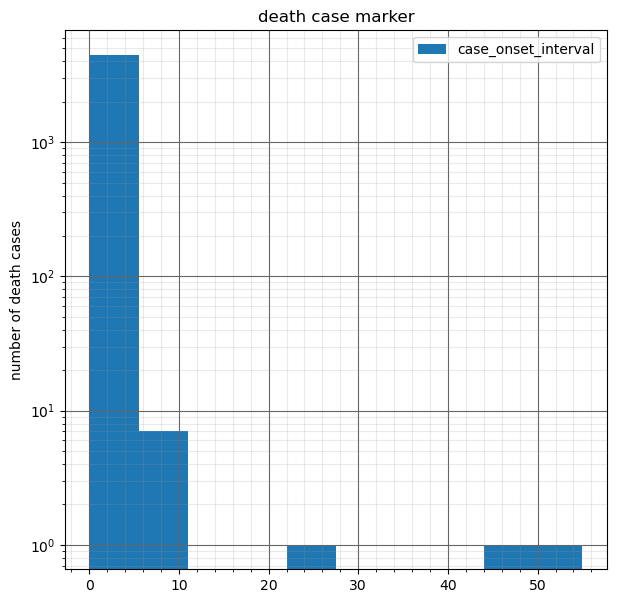

```python
# plot with log = True args
df[df['death_yn'] == "Yes"][['case_onset_interval']].plot(kind='hist',figsize=(7,7), bins=10, title="death case marker", log = True)
plt.grid(which='major', color='#666666', linestyle='-')
plt.ylabel('number of death cases')
plt.minorticks_on()
plt.grid(which='minor', color='#999999', linestyle='-', alpha=0.2)
```

We can see the stacked bar plot for case_onset_interval against the death_yn outcome.